# 52414: Lab 2

```r
potentials <- lm(Potential ~ (Value), data=potentials.players)
potentials.players$resid <- round(resid(potentials), 5)
potentials.players$fair_value <- round((potentials.players$Potential - potentials$coefficients[[1]]) / potentials$coefficients[[2]], 5)
print(potentials.players %>% arrange(desc(resid)) %>% select(Name, Age,Overall,Potential , Value, fair_value) %>% head(10))
```

```
##              Name Age Overall Potential   Value fair_value
## 1        A. Gomes  16      64        90  975000   19510043
## 2    W. Far\303\303±ez  19      73        87       0   15578617
## 3      M. Edwards  18      65        87 1200000   15578617
## 4       J. Sancho  17      63        86  800000   14268141
## 5     C. Fr\303¼chtl  17      65        86  975000   14268141
## 6        E. Barco  18      72        90 6500000   19510043
## 7    R. Sessegnon  17      67        86 1300000   14268141
## 8        J. Foyth  19      68        86 1700000   14268141
## 9  E. Abouchabaka  17      62        85  650000   12957666
## 10   D. Upamecano  18      69        86 2000000   14268141
```

```r
#q2d
nation_list <- fifa %>% select(Nationality) %>% na.omit()
nation_list <- recode_factor(nation_list$Nationality,"England"="United Kingdom",
                   "Scotland"="United Kingdom",
                   "Republic of Ireland"="United Kingdom",
                   "Wales"="United Kingdom",
                   "Czech Republic"="Czech Rep.")
nation_list_df <- as.data.frame(nation_list)
count_nation <- nation_list_df %>% count(nation_list) %>% rename("Count" = "n", "Nationality" = "nation_list")
join2map <- joinCountryData2Map(count_nation, joinCode = "NAME" , nameJoinColumn = "Nationality")
```

```
## 133 codes from your data successfully matched countries in the map
## 1 codes from your data failed to match with a country code in the map
## 110 codes from the map weren't represented in your data
```

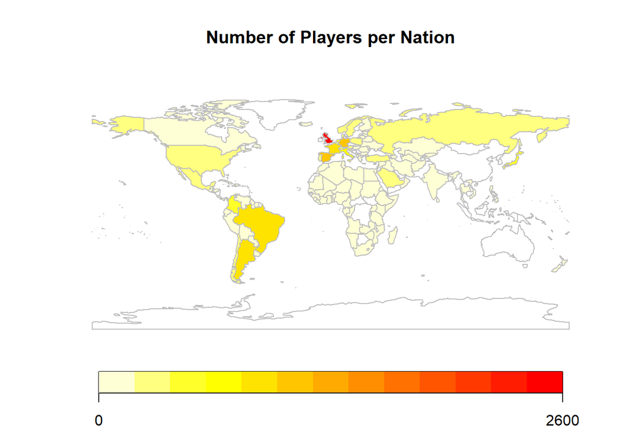

```r
map.of.players <- mapCountryData(join2map, "Count", numCats = 12, mapTitle = "Number of Players per Nation", lwd = 1.2, catMethod = c(seq(0,2600,200)))
```

```r
#q2e
mean_nation <- fifa %>% select(Nationality, Overall)
mean_nation$Nationality <- as.character(mean_nation$Nationality)
mean_nation$Nationality[mean_nation$Nationality == "England"] <- "United Kingdom"
mean_nation$Nationality[mean_nation$Nationality == "Wales"] <- "United Kingdom"
mean_nation$Nationality[mean_nation$Nationality == "Republic of Ireland"] <- "United Kingdom"
mean_nation$Nationality[mean_nation$Nationality == "Scotland"] <- "United Kingdom"
mean_nation$Nationality[mean_nation$Nationality == "Czech Republic"] <- "Czech Rep."

mean_nation <- mean_nation %>% group_by(Nationality) %>% summarise(Overall = mean(Overall))
join2map.b <- joinCountryData2Map(mean_nation, joinCode = "NAME" , nameJoinColumn = "Nationality")
```

```
## 133 codes from your data successfully matched countries in the map
## 1 codes from your data failed to match with a country code in the map
## 110 codes from the map weren't represented in your data
```

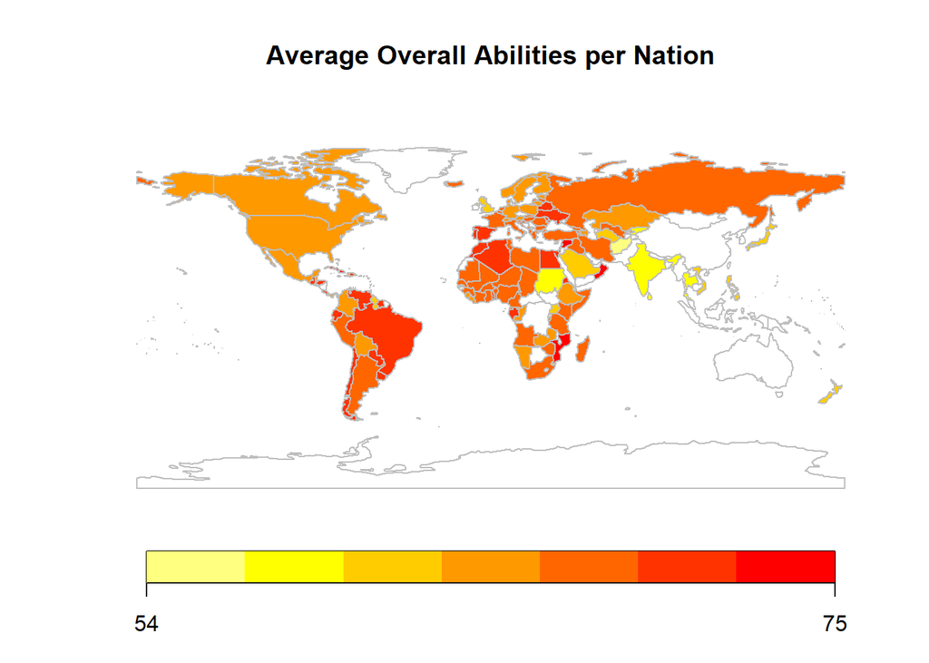

```r
map.of.players <- mapCountryData(join2map.b, "Overall", numCats = 7, mapTitle = "Average Overall Abilities per Nation",
                                 lwd = 1.2, catMethod = c(seq(54,75,3)))
```

## Q3. Correlations Analysis (30 pt)

In this question we find and display different skills and their correlations

1. We are interested in finding out which positions are similar in terms of players’ performance.  
   Extract the 26 non-goalkeeper positions (`CAM, CB, ..., ST`). Calculate the correlation between players’ ability in each pair of positions and show a heatmap correlation-plot of the correlations’ matrix. What three positions have the *least* average correlations with other skills?  
   We are interested in finding out which skills are similar in terms of players’ performance at the position. Extract the 29 skills for non-goalkeeper players (Acceleration, …, Volleys, except ’GK.*‘skills). Calculate the correlation between players’ ability in each pair of skills and show a heatmap correlation-plot of the correlations’ matrix. What two skills seem least correlated with other skills?

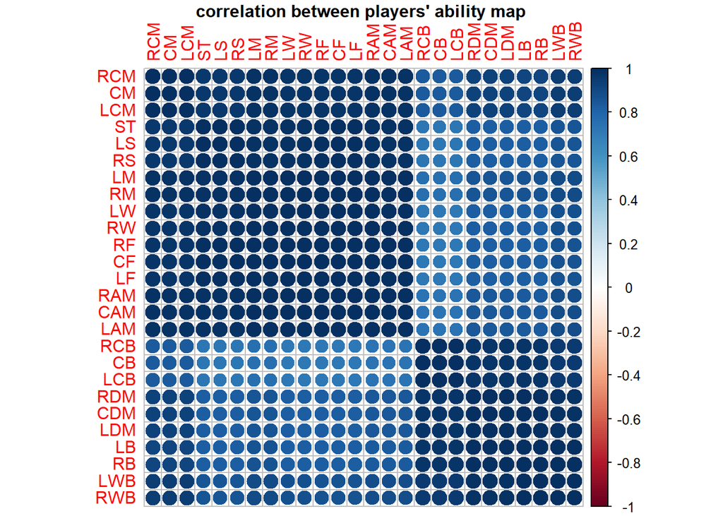

```r
position <-  fifa_players_positions %>% select(-c("ID","Preferred.Positions", "Overall" ,"Potential"))
corrplot(cor(position), order= "hclust" ,title = "correlation between players' ability map", cex.main=1, mar =c(0,0,1,0))
```

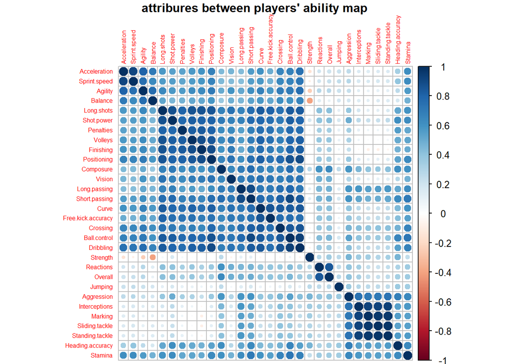

```r
attribures <- fifa_players_attribures[-c(1,13:17)]
corrplot(cor(attribures), order= "hclust" ,title = "attribures between players' ability map", cex.main=1, mar =c(0,0,1,0),cex.main=1, tl.cex = 0.5)
```

“rcb”, “cb”,“lcb” positions are least average correlated with other positions. strength and jumping are least correlated with other skills.

2. Consider the following indicators of players performance: `overall` players’ performance, their `potential`, their salary (`wage`) and their market `value`. Show a correlation-plot of players’ *34* skill levels (`Acceleration`, …, `Volleys`) vs. these four indicators. Find the *10* skills with the highest *average* correlation with the four inidcators and list them in a table.

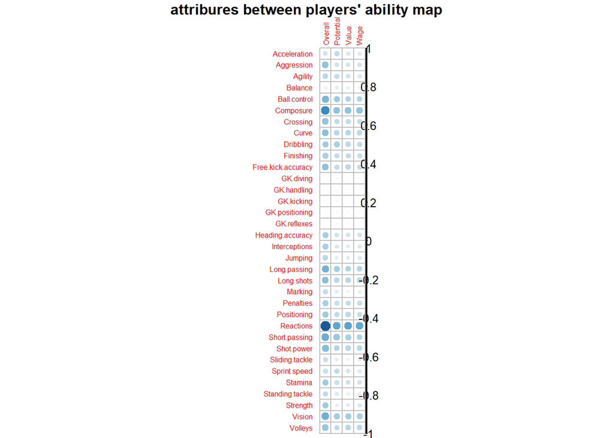

```r
performance <-cor( fifa_players_attribures[-c(1,36)],fifa_players_indicators[-1])
corrplot(performance ,title = "attribures between players' ability map", cex.main=1, mar =c(0,0,1,0),cex.main=1, tl.cex = 0.5)
```

```r
performance <- as.data.frame(performance)
performance$average <- ((performance$Overall+performance$Potential+performance$Value+performance$Wage)/4)
top_n(performance,10,average) %>% select(average) %>%  arrange((desc(average)))
```

```
##               average
## Reactions      0.5994
## Composure      0.4576
## Short.passing  0.3749
## Vision         0.3745
## Ball.control   0.3555
## Long.passing   0.3502
## Shot.power     0.3176
## Curve          0.3143
## Long.shots     0.3090
## Dribbling      0.2994
```

3. Build a team of *11 different* players with the following rules:
- For each of the *26* non-goalkeaper positions (*26* from above plus goalkeaper, `GK`), find the player with the best performance at this position.
- Find the goal keaper (`Preffered.Positions` is `GK`) with the best `overall` performance.
- From the players obtained above, find *11 distinct* players maximizing the average `overall` performance of the team, with the constraint that there must be a goalkeaper (preferred position `GK`).
- List the players in a table including their `overall` performance and the team average `overall` score.  
  Next, peak six *different* players of your choice from your team, one of which is the goalkeaper. Using the function `radarchart::chartJSRadar`, graph their abilities (individually for all 6 players) in the top *10* skills according to 3.b in a [radar chart](https://en.wikipedia.org/wiki/Radar_chart) (also called ‘spider chart’) graph. See below an example for such a chart.

```r
our_team <- fifa[c(2,6,46:71)]
dteamcandidates<-data.frame(col)
dteamcandidates<-our_team[0,]
for (i in 3:27){
    dteamcandidates<-add_row(dteamcandidates,our_team[which.max(our_team[,i]),])
    our_team=subset(our_team,Name!=dteamcandidates$Name[i-2])
    }
goal_keepers<-filter(fifa,fifa$Preferred.Positions=='GK ')
best_goal_keeper<-which.max(goal_keepers$Overall)
best_goal_keeper<-goal_keepers[best_goal_keeper,]
best_team<-distinct(dteamcandidates)
best_team<-best_team %>% arrange(desc(Overall)) %>% head(10)
best_team<-add_row(best_team,best_goal_keeper[c(2,6,46:71)])
best_team<-mutate(best_team,mean_Overall=rep(mean(best_team$Overall),11))
best_team
```

```
##                 Name Overall CAM CB CDM CF CM LAM LB LCB LCM LDM LF LM LS LW
## 1  Cristiano Ronaldo      94  89 53  62 91 82  89 61  53  82  62 91 89 92 91
## 2           L. Messi      93  92 45  59 92 84  92 57  45  84  59 92 90 88 91
## 3             Neymar      92  88 46  59 88 79  88 59  46  79  59 88 87 84 89
## 4         L. Su\303¡rez      92  87 58  65 88 80  87 64  58  80  65 88 85 88 87
## 5     R. Lewandowski      91  84 57  62 87 78  84 58  57  78  62 87 82 88 84
## 6       Sergio Ramos      90  70 87  83 70 74  70 84  87  74  83 70 71 72 69
## 7           T. Kroos      90  83 72  82 81 87  83 76  72  87  82 81 81 77 80
## 8          E. Hazard      90  88 47  61 87 81  88 59  47  81  61 87 87 82 88
## 9        G. Higua\303n      90  81 46  52 84 71  81 51  46  71  52 84 79 87 82
## 10      G. Chiellini      89  55 86  76 55 60  55 78  86  60  76 55 58 59 56
## 11          M. Neuer      92   0  0   0  0  0   0  0   0   0   0  0  0  0  0
##    LWB RAM RB RCB RCM RDM RF RM RS RW RWB ST mean_Overall
## 1   66  89 61  53  82  62 91 89 92 91  66 92        91.18
## 2   62  92 57  45  84  59 92 90 88 91  62 88        91.18
## 3   64  88 59  46  79  59 88 87 84 89  64 84        91.18
## 4   68  87 64  58  80  65 88 85 88 87  68 88        91.18
## 5   61  84 58  57  78  62 87 82 88 84  61 88        91.18
## 6   81  70 84  87  74  83 70 71 72 69  81 72        91.18
## 7   78  83 76  72  87  82 81 81 77 80  78 77        91.18
## 8   64  88 59  47  81  61 87 87 82 88  64 82        91.18
## 9   55  81 51  46  71  52 84 79 87 82  55 87        91.18
## 10  75  55 78  86  60  76 55 58 59 56  75 59        91.18
## 11   0   0  0   0   0   0  0  0  0  0   0  0        91.18
```

```r
team_chart<- best_team %>% arrange(Overall) %>% head(7)
team_chart<-subset(fifa,fifa$Name%in%team_chart$Name)
team_chart<-subset(team_chart,Overall>89)

team_chart<-team_chart %>% select(c(Name,Reactions,Composure,Short.passing,Vision,Ball.control,Long.passing,Shot.power,Curve,Long.shots,Dribbling))

x<-team_chart
df<-t(x[,2:ncol(x)])
colnames(df)<-x[,1]
df<-as.data.frame(df)

radarchart::chartJSRadar(df[1],labs=rownames(df))
```

[interactive chart not shown]

```r
radarchart::chartJSRadar(df[2],labs=rownames(df))
```

[interactive chart not shown]

```r
radarchart::chartJSRadar(df[3],labs=rownames(df))
```

[interactive chart not shown]

```r
radarchart::chartJSRadar(df[4],labs=rownames(df))
```

[interactive chart not shown]

```r
radarchart::chartJSRadar(df[5],labs=rownames(df))
```

[interactive chart not shown]

```r
radarchart::chartJSRadar(df[6],labs=rownames(df))
```

[interactive chart not shown]

4. We are interested in determining how the player’s abilities in different positions changes with age. Repeat the analysis of question 2.a., but this time show the *34* different skills  
   Which skills peak at youngest/oldest ages?

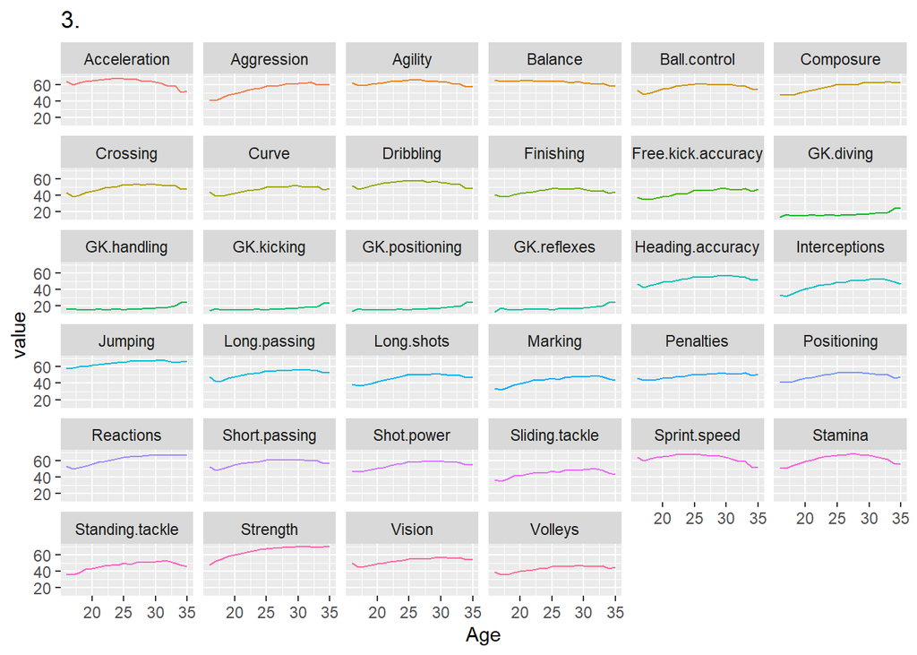

```r
different_skills <- fifa_players[,c(3,12:45)] %>% filter(Age<=35)
mean_different_skills <- aggregate(.~Age, data=different_skills, FUN=mean)
different_skills_Age <- melt(mean_different_skills, "Age")
ggplot(data=different_skills_Age, aes(x=Age, y=value, group=variable))+geom_line(aes(col=variable))+facet_wrap(~variable)+theme(legend.position = "none")+ggtitle("3.")
```

the skills that reaching the peak at the elder age are: Composure, Free kick accuracy, Reactions, Strength and GK skills, the skills that reaching the peak at the younger age are: Balance, Acceleration, Agility and Sprint speed

5. Your boss suggests that some players may be currently under-payed compared to their performance, and that we can acquire them by offering them a higher salary (`wage`).  
   Fit a multiple regression model predicting player’s `overall` performance based on their `wage` and `age`.  
   Find the $10$ players with the highest difference between their `wage` performance level and the regression model prediction, and list them in a table.

```r
wages <- fifa_players %>% select(Wage)
ages <- fifa_players %>% select(Age)
Overall <- fifa_players %>% select(Overall)
wage_age_overall <-cbind(wages,ages,Overall)
new_predict_temp <- lm(Overall~. ,data = wage_age_overall)
New_Predict <- new_predict_temp$fitted.values
wage_age_overall_1<-cbind(wage_age_overall,New_Predict)
Name <- fifa_players %>% select(Name)
wage_age_overall_2 <- cbind(Name,wage_age_overall_1)
wage_age_overall_2$Diff <- wage_age_overall_2$Overall- wage_age_overall_2$New_Predict
top_n(wage_age_overall_2, 10, Diff) %>% arrange(desc(Diff))
```

```
##              Name  Wage Age Overall New_Predict  Diff
## 1           Oscar     0  25      83       64.33 18.67
## 2      K. Mbapp\303© 31000  18      83       65.28 17.72
## 3    Adrien Silva     0  28      83       66.06 16.94
## 4     Sergio Rico 16000  23      82       65.75 16.25
## 5            Fred  1000  24      80       63.92 16.08
## 6   G. Donnarumma 35000  18      82       65.92 16.08
## 7        Grimaldo 12000  21      80       63.95 16.05
## 8       A. Witsel     0  28      82       66.06 15.94
## 9  Danilo Pereira 18000  25      83       67.22 15.78
## 10     K. Dolberg 10000  19      78       62.48 15.52
```

these players are under-payed compared to their performance, so we may think they are not as good as they really are, and they would agree to move to other team if we will offer higher salary.